# Graduate Rotational Internship Program

**Task 3 : Exploratory Data Analysis - Retail**  
**Submitted by- sneha sable**

**DATASET : SAMPLESUPERSTORE.CSV (https://bit.ly/3i4rbWl)**

```python
import pandas as pd
import numpy as np
import matplotlib.pyplot as plt
%matplotlib inline
import seaborn as sns
```

```python
data_set=pd.read_csv("SampleSuperstore.csv")
data_set
```

|  | Ship Mode | Segment | Country | City | State | Postal Code | Region | Category | Sub-Category | Sales | Quantity | Discount | Profit |
| --- | --- | --- | --- | --- | --- | --- | --- | --- | --- | --- | --- | --- | --- |
| 0 | Second Class | Consumer | United States | Henderson | Kentucky | 42420 | South | Furniture | Bookcases | 261.9600 | 2 | 0.00 | 41.9136 |
| 1 | Second Class | Consumer | United States | Henderson | Kentucky | 42420 | South | Furniture | Chairs | 731.9400 | 3 | 0.00 | 219.5820 |
| 2 | Second Class | Corporate | United States | Los Angeles | California | 90036 | West | Office Supplies | Labels | 14.6200 | 2 | 0.00 | 6.8714 |
| 3 | Standard Class | Consumer | United States | Fort Lauderdale | Florida | 33311 | South | Furniture | Tables | 957.5775 | 5 | 0.45 | -383.0310 |
| 4 | Standard Class | Consumer | United States | Fort Lauderdale | Florida | 33311 | South | Office Supplies | Storage | 22.3680 | 2 | 0.20 | 2.5164 |
| ... | ... | ... | ... | ... | ... | ... | ... | ... | ... | ... | ... | ... | ... |
| 9989 | Second Class | Consumer | United States | Miami | Florida | 33180 | South | Furniture | Furnishings | 25.2480 | 3 | 0.20 | 4.1028 |
| 9990 | Standard Class | Consumer | United States | Costa Mesa | California | 92627 | West | Furniture | Furnishings | 91.9600 | 2 | 0.00 | 15.6332 |
| 9991 | Standard Class | Consumer | United States | Costa Mesa | California | 92627 | West | Technology | Phones | 258.5760 | 2 | 0.20 | 19.3932 |
| 9992 | Standard Class | Consumer | United States | Costa Mesa | California | 92627 | West | Office Supplies | Paper | 29.6000 | 4 | 0.00 | 13.3200 |
| 9993 | Second Class | Consumer | United States | Westminster | California | 92683 | West | Office Supplies | Appliances | 243.1600 | 2 | 0.00 | 72.9480 |

9994 rows × 13 columns

```python
data_set.shape
```

```
(9994, 13)
```

```python
data_set.info()
```

```
<class 'pandas.core.frame.DataFrame'>
RangeIndex: 9994 entries, 0 to 9993
Data columns (total 13 columns):
 #   Column        Non-Null Count  Dtype
---  ------        --------------  -----
 0   Ship Mode     9994 non-null   object
 1   Segment       9994 non-null   object
 2   Country       9994 non-null   object
 3   City          9994 non-null   object
 4   State         9994 non-null   object
 5   Postal Code   9994 non-null   int64
 6   Region        9994 non-null   object
 7   Category      9994 non-null   object
 8   Sub-Category  9994 non-null   object
 9   Sales         9994 non-null   float64
 10  Quantity      9994 non-null   int64
 11  Discount      9994 non-null   float64
 12  Profit        9994 non-null   float64
dtypes: float64(3), int64(2), object(8)
memory usage: 1015.1+ KB
```

**Data contain an float and integer value.** **All the columns variable are non-null.**

```python
data_set.describe()
```

|  | Postal Code | Sales | Quantity | Discount | Profit |
| --- | --- | --- | --- | --- | --- |
| count | 9994.000000 | 9994.000000 | 9994.000000 | 9994.000000 | 9994.000000 |
| mean | 55190.379428 | 229.858001 | 3.789574 | 0.156203 | 28.656896 |
| std | 32063.693350 | 623.245101 | 2.225110 | 0.206452 | 234.260108 |
| min | 1040.000000 | 0.444000 | 1.000000 | 0.000000 | -6599.978000 |
| 25% | 23223.000000 | 17.280000 | 2.000000 | 0.000000 | 1.728750 |
| 50% | 56430.500000 | 54.490000 | 3.000000 | 0.200000 | 8.666500 |
| 75% | 90008.000000 | 209.940000 | 5.000000 | 0.200000 | 29.364000 |
| max | 99301.000000 | 22638.480000 | 14.000000 | 0.800000 | 8399.976000 |

```python
data_set.nunique()
```

```
Ship Mode          4
Segment            3
Country            1
City             531
State             49
Postal Code      631
Region             4
Category           3
Sub-Category      17
Sales           5825
Quantity          14
Discount          12
Profit          7287
dtype: int64
```

```python
# checking for duplicate values
data_set.duplicated().sum()
```

```
17
```

```python
#dropping duplicate values from the dataset
data_set.drop_duplicates()
```

|  | Ship Mode | Segment | Country | City | State | Postal Code | Region | Category | Sub-Category | Sales | Quantity | Discount | Profit |
| --- | --- | --- | --- | --- | --- | --- | --- | --- | --- | --- | --- | --- | --- |
| 0 | Second Class | Consumer | United States | Henderson | Kentucky | 42420 | South | Furniture | Bookcases | 261.9600 | 2 | 0.00 | 41.9136 |
| 1 | Second Class | Consumer | United States | Henderson | Kentucky | 42420 | South | Furniture | Chairs | 731.9400 | 3 | 0.00 | 219.5820 |
| 2 | Second Class | Corporate | United States | Los Angeles | California | 90036 | West | Office Supplies | Labels | 14.6200 | 2 | 0.00 | 6.8714 |
| 3 | Standard Class | Consumer | United States | Fort Lauderdale | Florida | 33311 | South | Furniture | Tables | 957.5775 | 5 | 0.45 | -383.0310 |
| 4 | Standard Class | Consumer | United States | Fort Lauderdale | Florida | 33311 | South | Office Supplies | Storage | 22.3680 | 2 | 0.20 | 2.5164 |
| ... | ... | ... | ... | ... | ... | ... | ... | ... | ... | ... | ... | ... | ... |
| 9989 | Second Class | Consumer | United States | Miami | Florida | 33180 | South | Furniture | Furnishings | 25.2480 | 3 | 0.20 | 4.1028 |
| 9990 | Standard Class | Consumer | United States | Costa Mesa | California | 92627 | West | Furniture | Furnishings | 91.9600 | 2 | 0.00 | 15.6332 |
| 9991 | Standard Class | Consumer | United States | Costa Mesa | California | 92627 | West | Technology | Phones | 258.5760 | 2 | 0.20 | 19.3932 |
| 9992 | Standard Class | Consumer | United States | Costa Mesa | California | 92627 | West | Office Supplies | Paper | 29.6000 | 4 | 0.00 | 13.3200 |
| 9993 | Second Class | Consumer | United States | Westminster | California | 92683 | West | Office Supplies | Appliances | 243.1600 | 2 | 0.00 | 72.9480 |

9977 rows × 13 columns

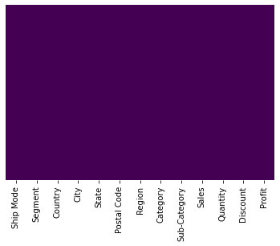

```python
sns.heatmap(data_set.isnull(), cbar=False, yticklabels=False, cmap='viridis')
```

**From above we can see there is no missing values in the dataset.**

# Analysis using Pairplot of each column

**Based on Category**

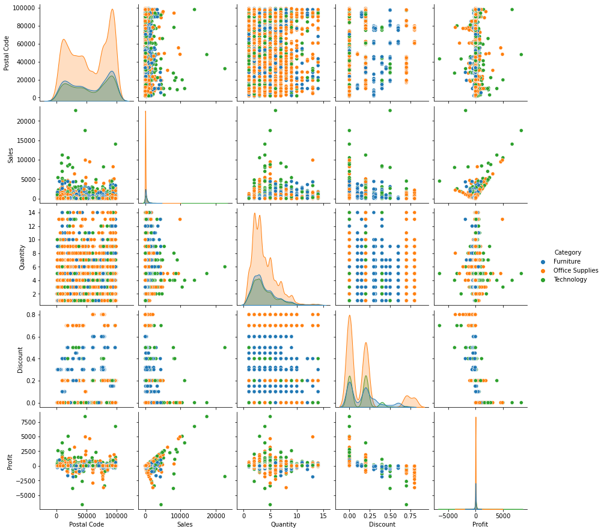

```python
sns.pairplot(data_set, hue = 'Category')
```

**Based on Region**

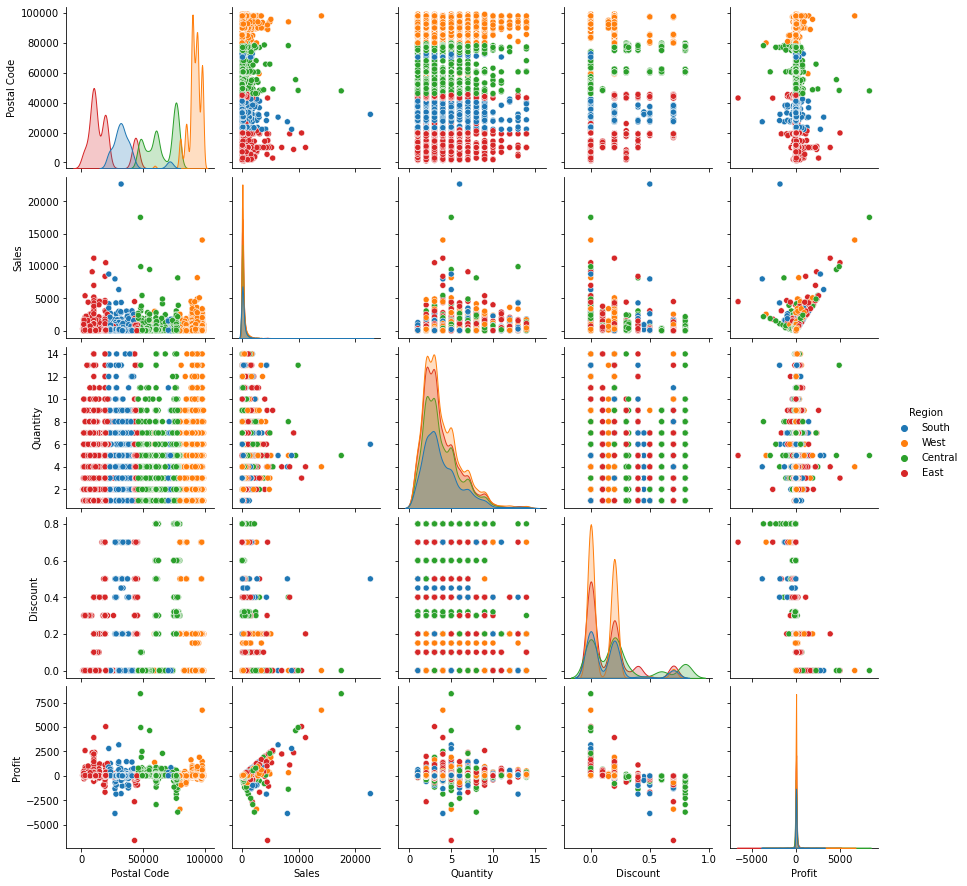

```python
sns.pairplot(data_set, hue = 'Region')
```

**Based on Segment**

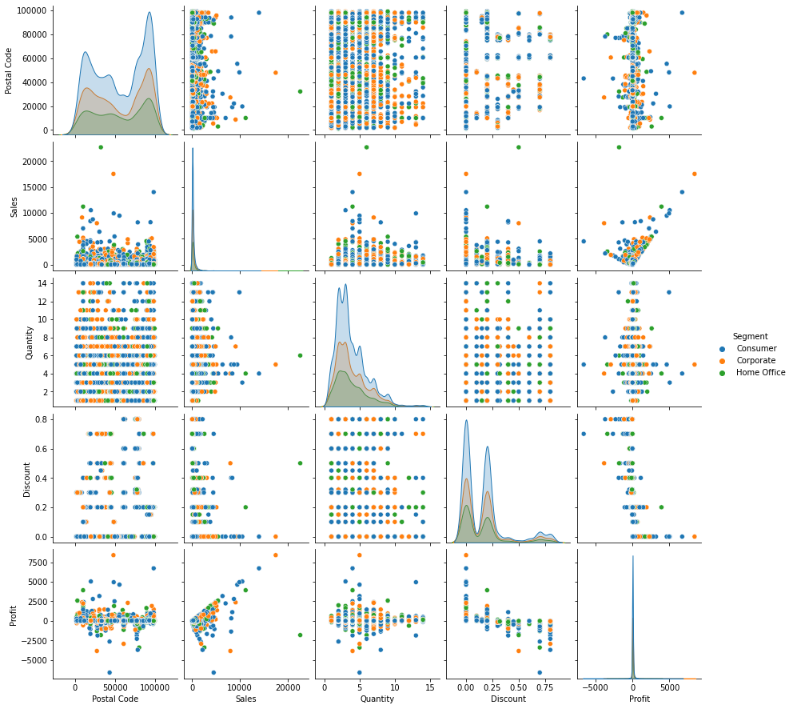

```python
sns.pairplot(data_set, hue = 'Segment')
```

**Based on Sub-Category**

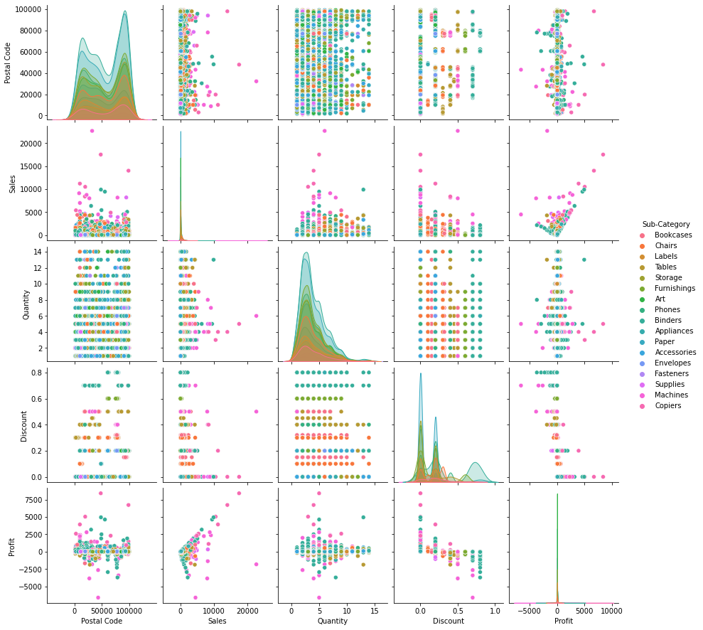

```python
sns.pairplot(data_set, hue = 'Sub-Category')
```

# Exploratory Data Analysis

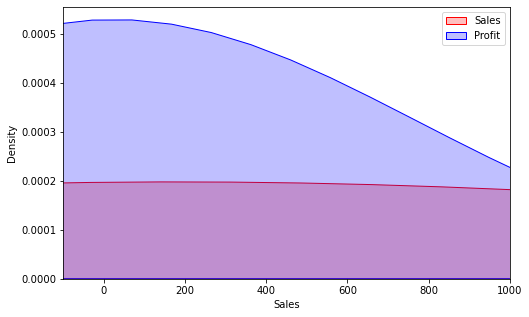

```python
plt.figure(figsize=(8,5))
sns.kdeplot(data_set['Sales'],color='red',label='Sales',shade=True,bw_adjust=20)
sns.kdeplot(data_set['Profit'],color='Blue',label='Profit',shade=True,bw_adjust=20)
plt.xlim([-100,1000])
plt.legend()
```

# CATEGORIES VS REGION

[output not shown]

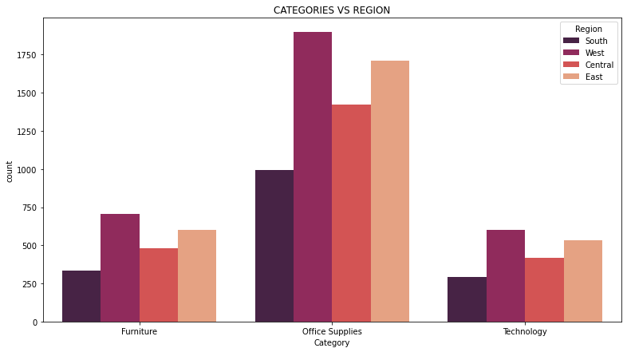

```python
plt.figure(figsize=(13,7))
plt.title('CATEGORIES VS REGION')
sns.countplot(x=data_set['Category'],hue=data_set['Region'],palette='rocket')
plt.xticks()
```

# Category VS Sub-Category

[output not shown]

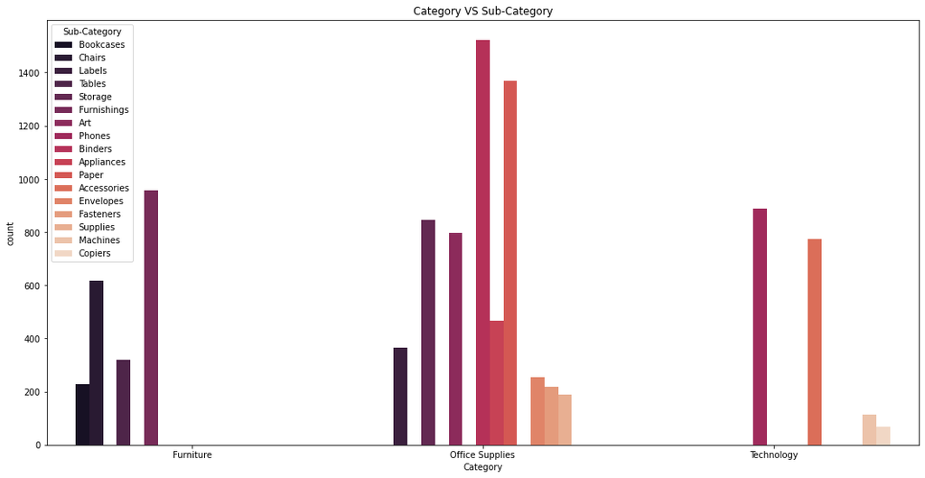

```python
plt.figure(figsize=(18,9))
plt.title('Category VS Sub-Category')
sns.countplot(x=data_set['Category'],hue=data_set['Sub-Category'],palette='rocket')
plt.xticks()
```

# Sales vs Profit

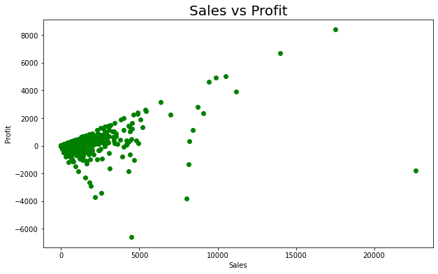

```python
plt.subplots(figsize=(10,6))
plt.scatter(data_set['Sales'],data_set['Profit'],color='green')
plt.xlabel('Sales')
plt.ylabel("Profit")
plt.title('Sales vs Profit',fontsize=20)
plt.show()
```

**Most sales are less than USD$5k**

**A significant number of transactions under USD$2.5k result in a loss.**

**Larger sales above USD$2.5k are very likely to result in a profit.**

```python
# correlation matrix of the data
data_set.corr()
```

|  | Postal Code | Sales | Quantity | Discount | Profit |
| --- | --- | --- | --- | --- | --- |
| Postal Code | 1.000000 | -0.023854 | 0.012761 | 0.058443 | -0.029961 |
| Sales | -0.023854 | 1.000000 | 0.200795 | -0.028190 | 0.479064 |
| Quantity | 0.012761 | 0.200795 | 1.000000 | 0.008623 | 0.066253 |
| Discount | 0.058443 | -0.028190 | 0.008623 | 1.000000 | -0.219487 |
| Profit | -0.029961 | 0.479064 | 0.066253 | -0.219487 | 1.000000 |

```python
# covariance matrix of data
data_set.cov()
```

|  | Postal Code | Sales | Quantity | Discount | Profit |
| --- | --- | --- | --- | --- | --- |
| Postal Code | 1.028080e+09 | -476682.766590 | 910.415885 | 386.870404 | -225045.849445 |
| Sales | -4.766828e+05 | 388434.455308 | 278.459923 | -3.627228 | 69944.096586 |
| Quantity | 9.104159e+02 | 278.459923 | 4.951113 | 0.003961 | 34.534769 |
| Discount | 3.868704e+02 | -3.627228 | 0.003961 | 0.042622 | -10.615173 |
| Profit | -2.250458e+05 | 69944.096586 | 34.534769 | -10.615173 | 54877.798055 |

**Heatmap for Correlation**

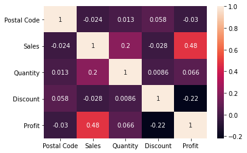

```python
sns.heatmap(data_set.corr(),annot= True,cmap = 'rocket')
plt.figure(figsize=(14,7))
```

**From above Heatmap:**

1.**Sales and Profit are Moderately Correlated.**

2.**Discount and Profit are Negatively Correlated**

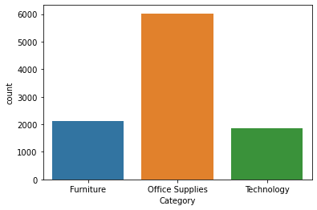

```python
sns.countplot(data_set['Category'])
plt.figure(figsize=(15,7))
```

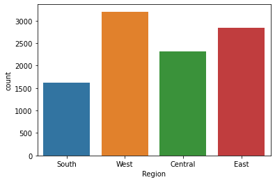

```python
sns.countplot(data_set['Region'])
plt.figure(figsize=(12,6))
```

# Count plot of each coloumn

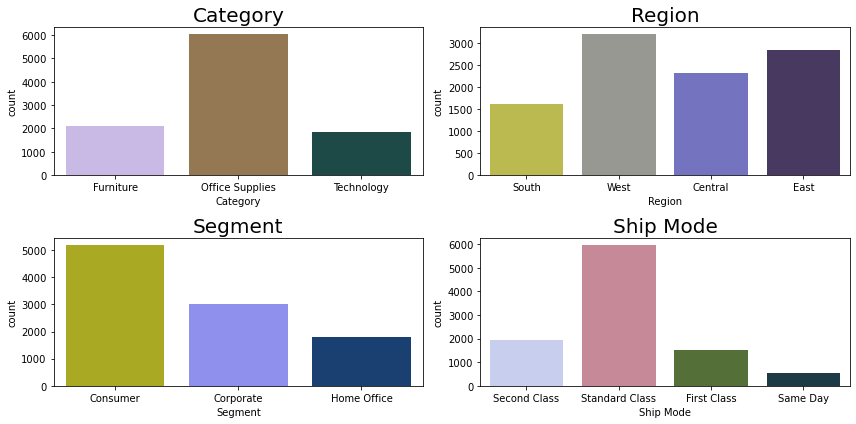

```python
fig, axs = plt.subplots(nrows = 2,ncols = 2,figsize = (12,6))
sns.countplot(data_set['Category'],ax = axs[0][0],palette='cubehelix_r')
sns.countplot(data_set['Region'],ax = axs[0][1],palette='gist_stern_r')
sns.countplot(data_set['Segment'],ax = axs[1][0],palette='gist_stern_r')
sns.countplot(data_set['Ship Mode'],ax = axs[1][1],palette='cubehelix_r')
axs[0][0].set_title('Category',fontsize=20)
axs[0][1].set_title('Region',fontsize=20)
axs[1][0].set_title('Segment',fontsize=20)
axs[1][1].set_title('Ship Mode',fontsize=20)
plt.tight_layout()
```

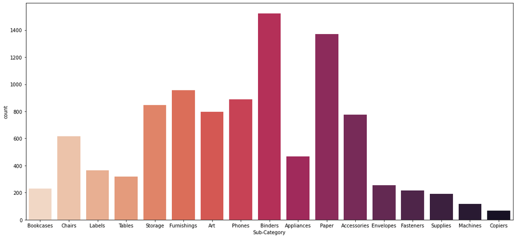

```python
plt.figure(figsize=(15,7))
sns.countplot(data_set['Sub-Category'], palette='rocket_r')
plt.tight_layout()
```

```python
data_set['Quantity'].value_counts()
```

```
3     2409
2     2402
5     1230
4     1191
1      899
7      606
6      572
9      258
8      257
10      57
11      34
14      29
13      27
12      23
Name: Quantity, dtype: int64
```

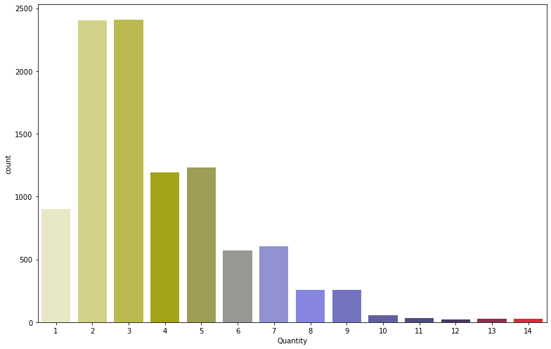

```python
plt.figure(figsize=(11,7))
sns.countplot(data_set['Quantity'], palette='gist_stern_r')
plt.tight_layout()
```

```python
data_set['State'].value_counts()
```

```
California              2001
New York                1128
Texas                    985
Pennsylvania             587
Washington               506
Illinois                 492
Ohio                     469
Florida                  383
Michigan                 255
North Carolina           249
Arizona                  224
Virginia                 224
Georgia                  184
Tennessee                183
Colorado                 182
Indiana                  149
Kentucky                 139
Massachusetts            135
New Jersey               130
Oregon                   124
Wisconsin                110
Maryland                 105
Delaware                  96
Minnesota                 89
Connecticut               82
Oklahoma                  66
Missouri                  66
Alabama                   61
Arkansas                  60
Rhode Island              56
Mississippi               53
Utah                      53
South Carolina            42
Louisiana                 42
Nevada                    39
Nebraska                  38
New Mexico                37
Iowa                      30
New Hampshire             27
Kansas                    24
Idaho                     21
Montana                   15
South Dakota              12
Vermont                   11
District of Columbia      10
Maine                      8
North Dakota               7
West Virginia              4
Wyoming                    1
Name: State, dtype: int64
```

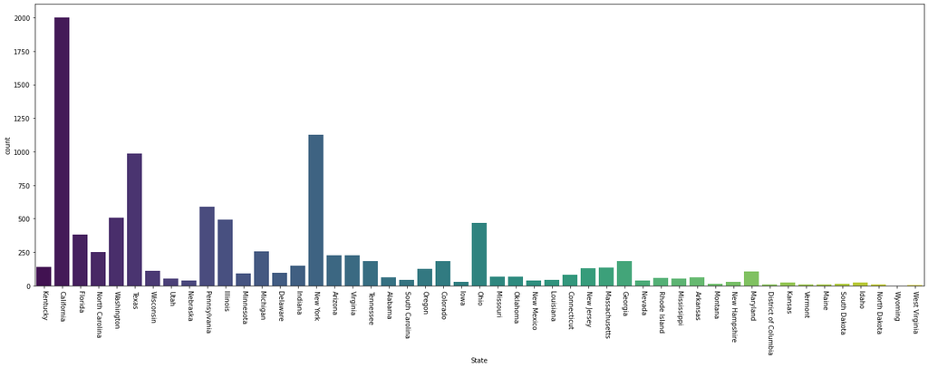

```python
plt.figure(figsize=(20,8))
sns.countplot(data_set['State'], palette='viridis')
plt.xticks(rotation=270)
plt.tight_layout()
```

```python
data_set['Discount'].value_counts()
```

```
0.00    4798
0.20    3657
0.70     418
0.80     300
0.30     227
0.40     206
0.60     138
0.10      94
0.50      66
0.15      52
0.32      27
0.45      11
Name: Discount, dtype: int64
```

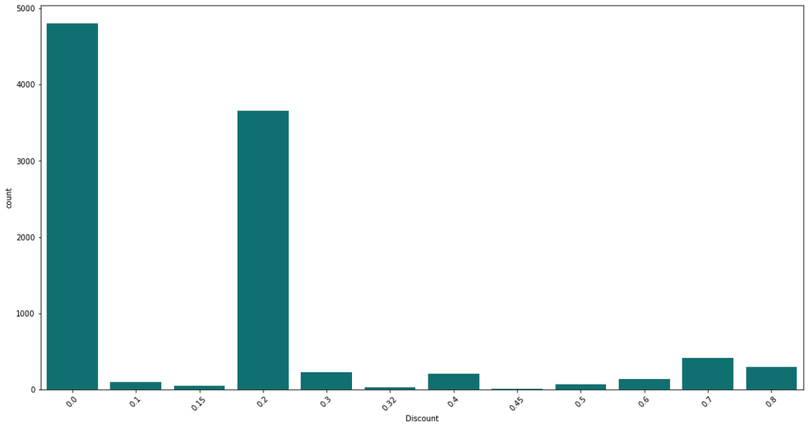

```python
plt.figure(figsize=(15,8))
sns.countplot(data_set['Discount'], color='Teal')
plt.xticks(rotation=45)
plt.tight_layout()
```

# Distribution Of Data

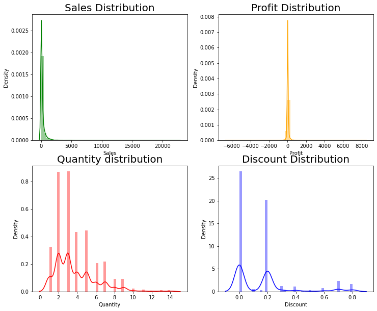

```python
fig, axs = plt.subplots(ncols=2, nrows = 2, figsize = (12,10))
sns.distplot(data_set['Sales'], color = 'green',  ax = axs[0][0])
sns.distplot(data_set['Profit'], color = 'orange',  ax = axs[0][1])
sns.distplot(data_set['Quantity'], color = 'red',  ax = axs[1][0])
sns.distplot(data_set['Discount'], color = 'blue',  ax = axs[1][1])
axs[0][0].set_title('Sales Distribution', fontsize = 20)
axs[0][1].set_title('Profit Distribution', fontsize = 20)
axs[1][0].set_title('Quantity distribution', fontsize = 20)
axs[1][1].set_title('Discount Distribution', fontsize = 20)
plt.show()
```

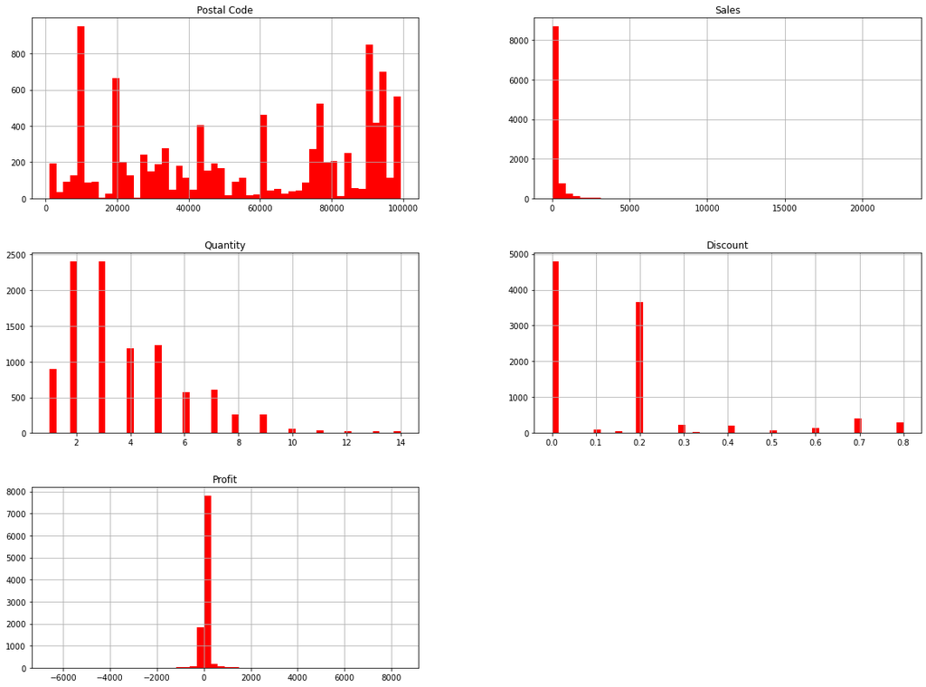

```python
data_set.hist(bins=50,figsize=(20,15),color='red')
plt.show()
```

# State wise Analysis

```python
df=data_set['State'].value_counts()
df.head(10)
```

```
California        2001
New York          1128
Texas              985
Pennsylvania       587
Washington         506
Illinois           492
Ohio               469
Florida            383
Michigan           255
North Carolina     249
Name: State, dtype: int64
```

```python
df_states=data_set.groupby(['State'])[['Sales','Discount','Profit']].mean()
df_states.head(10)
```

| State | Sales | Discount | Profit |
| --- | --- | --- | --- |
| Alabama | 319.846557 | 0.000000 | 94.865989 |
| Arizona | 157.508933 | 0.303571 | -15.303235 |
| Arkansas | 194.635500 | 0.000000 | 66.811452 |
| California | 228.729451 | 0.072764 | 38.171608 |
| Colorado | 176.418231 | 0.316484 | -35.867351 |
| Connecticut | 163.223866 | 0.007317 | 42.823071 |
| Delaware | 285.948635 | 0.006250 | 103.930988 |
| District of Columbia | 286.502000 | 0.000000 | 105.958930 |
| Florida | 233.612815 | 0.299347 | -8.875461 |
| Georgia | 266.825217 | 0.000000 | 88.315453 |

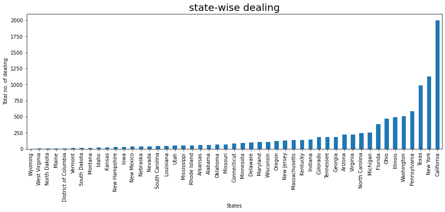

```python
df_state = data_set.groupby('State')['Quantity'].count().sort_values(ascending=True).plot.bar(figsize=(15,5))
plt.title('state-wise dealing',fontsize=20)
plt.xlabel('States')
plt.ylabel('Total no. of dealing')
plt.show()
```

**State-wise dealing:**

**California has the highest dealings in the state with almost 2K of total dealings.**

**New York has the second highest dealings with around 1,120 of total dealings.**

**Texas is third with almost 1K of total dealings.**

**Wyoming has lowest dealings**

# Profit Analysis Statewise

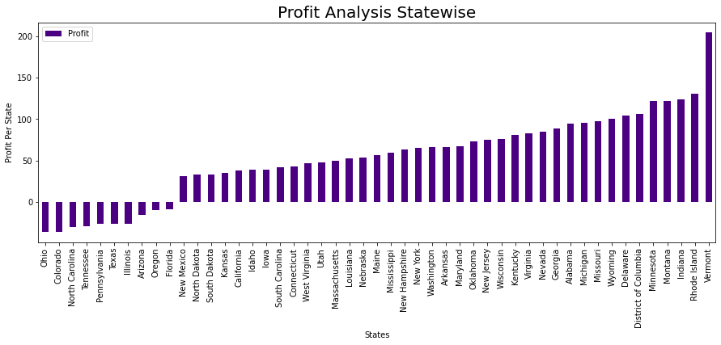

```python
df1=df_states.sort_values('Profit')

df1['Profit'].plot(kind= 'bar',figsize=(15,5),color='indigo')
plt.xlabel('States')
plt.ylabel('Profit Per State')
plt.title('Profit Analysis Statewise', fontsize=20)
plt.legend()
```

**Profit Analysis Statewise:**

**Vermont state has Highest Profit &** **Ohio state has Lowest Profit**

# Sales Analysis Statewise

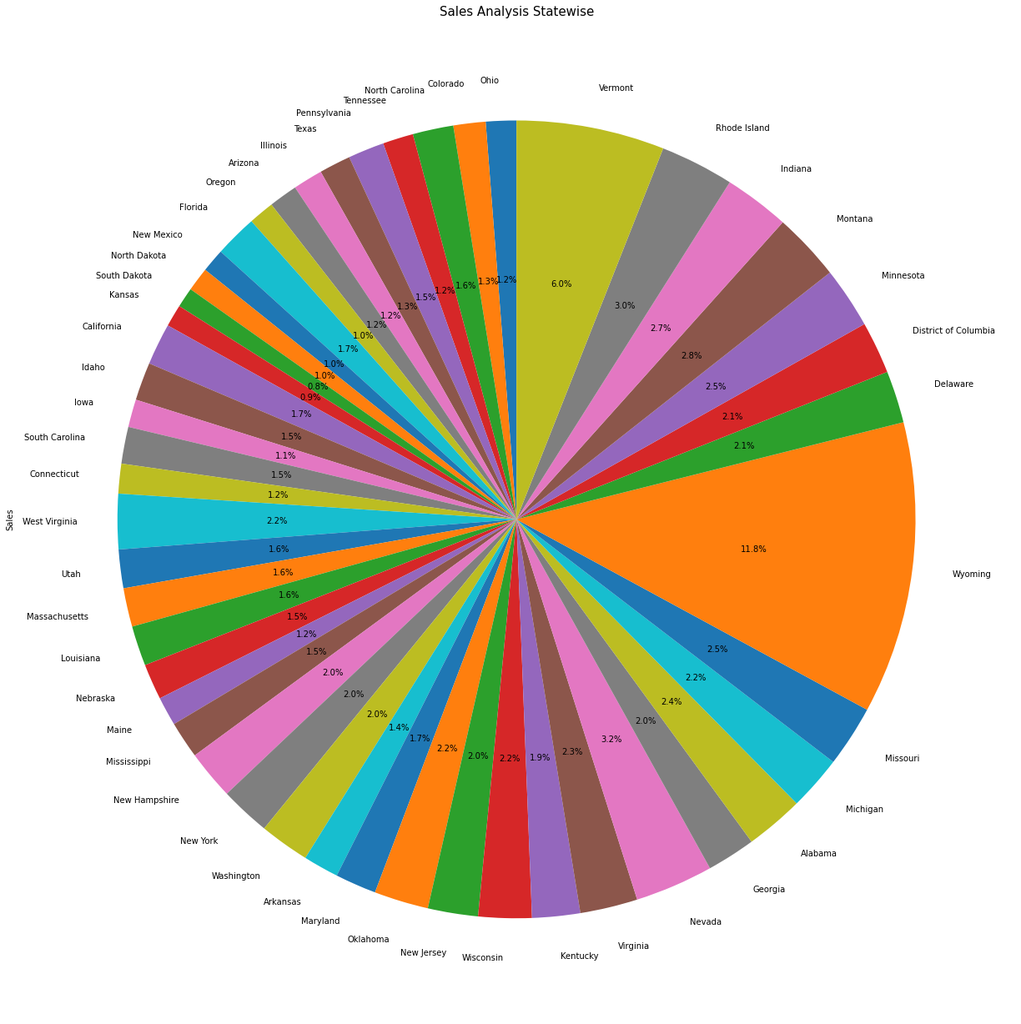

```python
df1['Sales'].plot(kind= 'pie',figsize=(22,22),autopct='%1.1f%%',startangle=90)
plt.title('Sales Analysis Statewise', fontsize=15)
```

**Sales Analysis Statewise:**

# Discount Analysis Statewise

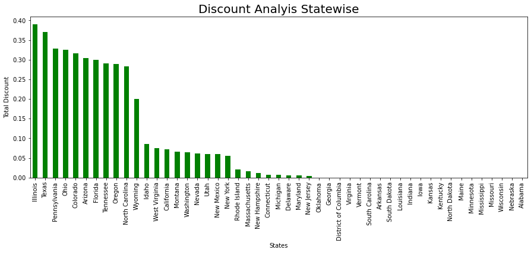

```python
df_discount = data_set.groupby('State')['Discount'].mean().sort_values(ascending=False).plot.bar(figsize=(15,5),color='green')
plt.title('Discount Analyis Statewise',fontsize=20)
plt.xlabel('States')
plt.ylabel('Total Discount')
plt.show()
```

**Discount Analyis Statewise:**

**Illinois state has Highest total Discount**

```python
segment=data_set.Segment.value_counts().reset_index()
segment.columns=("Segment","Count")
segment
```

|  | Segment | Count |
| --- | --- | --- |
| 0 | Consumer | 5191 |
| 1 | Corporate | 3020 |
| 2 | Home Office | 1783 |

[output not shown]

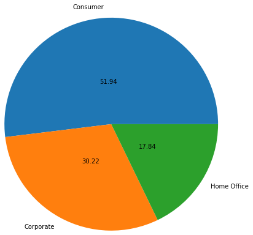

```python
plt.pie(x="Count",labels="Segment",data=segment,radius=2,autopct="%.2f",pctdistance=0.4)
```

# Top 5 cities by Sales,Profit,Discount

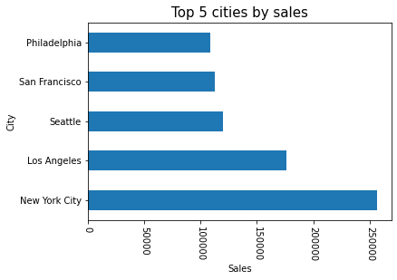

```python
total_sales = data_set.groupby('City')['Sales'].sum()

top_5_cities = total_sales.sort_values(ascending = False).iloc[0:5]
top_5_cities.plot(kind = 'barh')
plt.title('Top 5 cities by sales',fontsize=15)
plt.xticks(rotation=270)
plt.xlabel('Sales')
plt.show()
```

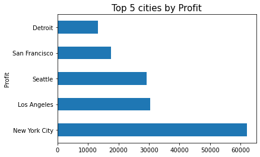

```python
total_profit = data_set.groupby('City')['Profit'].sum()

top_5_cities = total_profit.sort_values(ascending= False).iloc[0:5]
top_5_cities.plot(kind = 'barh')
plt.title('Top 5 cities by Profit',fontsize=15)
plt.ylabel('Profit')
```

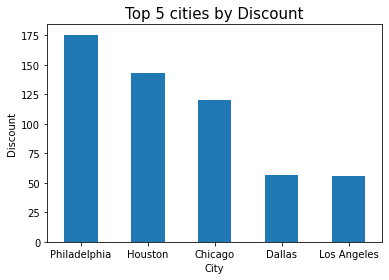

```python
total_profit = data_set.groupby('City')['Discount'].sum()

top_5_cities = total_profit.sort_values(ascending= False).iloc[0:5]
top_5_cities.plot(kind = 'bar')
plt.title('Top 5 cities by Discount',fontsize=15)
plt.xticks(rotation=0)
plt.ylabel('Discount')
```

# Sales by Region

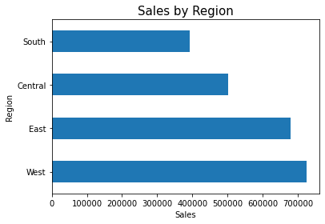

```python
total_sales = data_set.groupby('Region')['Sales'].sum()

region_sales = total_sales.sort_values(ascending = False).iloc[0:4]
region_sales.plot(kind ='barh')
plt.title('Sales by Region',fontsize=15)
plt.xlabel('Sales')
plt.show()
```

# Sales by Segment

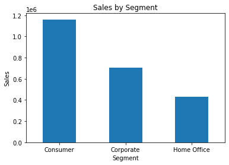

```python
total_profit = data_set.groupby('Segment')['Sales'].sum()

segment_sales = total_profit.sort_values(ascending= False).iloc[0:4]
segment_sales.plot(kind = 'bar',fontsize=10)
plt.title('Sales by Segment')
plt.xticks(rotation=0)
plt.ylabel('Sales')
```

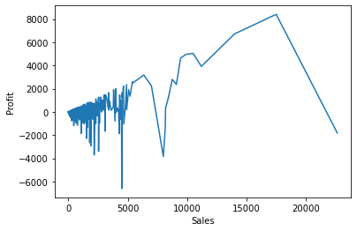

```python
sns.lineplot(x='Sales',y='Profit',data = data_set)
plt.show()
```

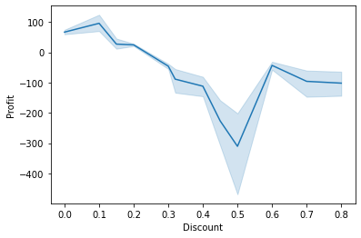

```python
sns.lineplot(x='Discount',y='Profit',data = data_set)
plt.show()
```